# Weight Lifting Exercise Manner Prediction

hoaihuongbk

8/24/2019

## Overview

Using devices such as Jawbone Up, Nike FuelBand, and Fitbit it is now possible to collect a large amount of data about personal activity relatively inexpensively. These type of devices are part of the quantified self movement – a group of enthusiasts who take measurements about themselves regularly to improve their health, to find patterns in their behavior, or because they are tech geeks. One thing that people regularly do is quantify how much of a particular activity they do, but they rarely quantify how well they do it. In this project, your goal will be to use data from accelerometers on the belt, forearm, arm, and dumbell of 6 participants. They were asked to perform barbell lifts correctly and incorrectly in 5 different ways. More information is available from the website here: http://groupware.les.inf.puc-rio.br/har (see the section on the Weight Lifting Exercise Dataset).

## Goal

The goal of my report is to predict the manner in which they did the exercise. This is the “classe” variable in the training set. After that, use the prediction model to predict 20 different test cases.

## Data Pre-Processing

The training data for this report are available here: https://d396qusza40orc.cloudfront.net/predmachlearn/pml-training.csv

The test data are available here: https://d396qusza40orc.cloudfront.net/predmachlearn/pml-testing.csv

```r
training <- read.csv("./pml-training.csv", na.strings = c("NA", "#DIV/0!", ""))
testing <- read.csv("./pml-testing.csv", na.strings = c("NA", "#DIV/0!", ""))
str(training)
```

```
## 'data.frame':    19622 obs. of  160 variables:
##  $ X                       : int  1 2 3 4 5 6 7 8 9 10 ...
##  $ user_name               : Factor w/ 6 levels "adelmo","carlitos",..: 2 2 2 2 2 2 2 2 2 2 ...
##  $ raw_timestamp_part_1    : int  1323084231 1323084231 1323084231 1323084232 1323084232 1323084232 1323084232 1323084232 1323084232 1323084232 ...
##  $ raw_timestamp_part_2    : int  788290 808298 820366 120339 196328 304277 368296 440390 484323 484434 ...
##  $ cvtd_timestamp          : Factor w/ 20 levels "02/12/2011 13:32",..: 9 9 9 9 9 9 9 9 9 9 ...
##  $ new_window              : Factor w/ 2 levels "no","yes": 1 1 1 1 1 1 1 1 1 1 ...
##  $ num_window              : int  11 11 11 12 12 12 12 12 12 12 ...
##  $ roll_belt               : num  1.41 1.41 1.42 1.48 1.48 1.45 1.42 1.42 1.43 1.45 ...
##  $ pitch_belt              : num  8.07 8.07 8.07 8.05 8.07 8.06 8.09 8.13 8.16 8.17 ...
##  $ yaw_belt                : num  -94.4 -94.4 -94.4 -94.4 -94.4 -94.4 -94.4 -94.4 -94.4 -94.4 ...
##  $ total_accel_belt        : int  3 3 3 3 3 3 3 3 3 3 ...
##  $ kurtosis_roll_belt      : num  NA NA NA NA NA NA NA NA NA NA ...
##  $ kurtosis_picth_belt     : num  NA NA NA NA NA NA NA NA NA NA ...
##  $ kurtosis_yaw_belt       : logi  NA NA NA NA NA NA ...
```

[output cut: 86 more lines]

You can see there are many column with NA in training data, we should remove them first.Also, remove 7 columns from begining, because we don’t use it in this report.

```r
training <- training[, colSums(is.na(training)) == 0]
testing <- testing[, colSums(is.na(testing)) == 0]
training <- training[, -c(1:7)]
testing <- testing[, -c(1:7)]
dim(training)
```

```
## [1] 19622    53
```

```r
dim(testing)
```

```
## [1] 20 53
```

For validation test, we will split training data into 2 part with 60% percentage for train and 40% for validation.

```r
library(caret)
set.seed(280890)
inTrain <- createDataPartition(training$classe, p=0.6, list=FALSE)
train <- training[inTrain,]
validation <- training[-inTrain,]
dim(train)
```

```
## [1] 11776    53
```

```r
dim(validation)
```

```
## [1] 7846   53
```

## Prediction Models

We will use some algorithms:

- Classification Tree
- Random Forest
- Generalized boosted regression (GBR)

For each algorithm, we use `train` dataset for train data and `validation` dataset for validation test.

### Classification Tree

```r
control <- trainControl(method = "cv", number = 5)
model_ct <- train(classe ~ ., data=train, method="rpart", trControl=control)
print(model_ct, digits = 4)
```

```
## CART
##
## 11776 samples
##    52 predictor
##     5 classes: 'A', 'B', 'C', 'D', 'E'
##
## No pre-processing
## Resampling: Cross-Validated (5 fold)
##
## Summary of sample sizes: 9420, 9421, 9420, 9421, 9422
##
## Resampling results across tuning parameters:
##
##   cp       Accuracy  Kappa    Accuracy SD  Kappa SD
##   0.03085  0.5450    0.41755  0.03949      0.06295
##   0.04509  0.4502    0.26751  0.08028      0.13572
##   0.11509  0.3335    0.07517  0.04480      0.06876
##
## Accuracy was used to select the optimal model using  the largest value.
## The final value used for the model was cp = 0.03085.
```

```r
predict_ct <- predict(model_ct, validation)
confusion_ct <- confusionMatrix(validation$classe, predict_ct)
accuracy_ct <- confusion_ct$overall[1]
accuracy_ct
```

```
##  Accuracy
## 0.5345399
```

### Random Forest

```r
model_rf <- train(classe ~ ., data = train, method = "rf", trControl = control)
print(model_rf, digits = 4)
```

```
## Random Forest
##
## 11776 samples
##    52 predictor
##     5 classes: 'A', 'B', 'C', 'D', 'E'
##
## No pre-processing
## Resampling: Cross-Validated (5 fold)
##
## Summary of sample sizes: 9420, 9421, 9420, 9421, 9422
##
## Resampling results across tuning parameters:
##
##   mtry  Accuracy  Kappa   Accuracy SD  Kappa SD
##    2    0.9893    0.9865  0.0009194    0.001165
##   27    0.9893    0.9865  0.0023518    0.002976
##   52    0.9847    0.9807  0.0038316    0.004849
##
## Accuracy was used to select the optimal model using  the largest value.
## The final value used for the model was mtry = 27.
```

```r
predict_rf <- predict(model_rf, validation)
confusion_rf <- confusionMatrix(validation$classe, predict_rf)
accuracy_rf <- confusion_rf$overall[1]
accuracy_rf
```

```
##  Accuracy
## 0.9901861
```

### Generalized boosted regression (GBR)

```r
model_gbm <- train(classe ~ ., data=train, method="gbm", trControl = control, verbose = FALSE)
print(model_gbm, digits = 4)
```

```
## Stochastic Gradient Boosting
##
## 11776 samples
##    52 predictor
##     5 classes: 'A', 'B', 'C', 'D', 'E'
##
## No pre-processing
## Resampling: Cross-Validated (5 fold)
##
## Summary of sample sizes: 9422, 9421, 9420, 9421, 9420
##
## Resampling results across tuning parameters:
##
##   interaction.depth  n.trees  Accuracy  Kappa   Accuracy SD  Kappa SD
##   1                   50      0.7532    0.6874  0.009433     0.011698
##   1                  100      0.8205    0.7728  0.005801     0.007210
##   1                  150      0.8544    0.8159  0.011139     0.013911
##   2                   50      0.8553    0.8167  0.006268     0.007893
##   2                  100      0.9047    0.8794  0.006033     0.007616
##   2                  150      0.9311    0.9129  0.006537     0.008250
##   3                   50      0.8967    0.8692  0.008019     0.010093
##   3                  100      0.9427    0.9275  0.009664     0.012219
##   3                  150      0.9602    0.9496  0.006656     0.008422
##
## Tuning parameter 'shrinkage' was held constant at a value of 0.1
##
## Tuning parameter 'n.minobsinnode' was held constant at a value of 10
## Accuracy was used to select the optimal model using  the largest value.
## The final values used for the model were n.trees = 150,
##  interaction.depth = 3, shrinkage = 0.1 and n.minobsinnode = 10.
```

```r
predict_gbm <- predict(model_gbm, validation)
confusion_gbm <- confusionMatrix(validation$classe, predict_gbm)
accuracy_gbm <- confusion_gbm$overall[1]
accuracy_gbm
```

```
##  Accuracy
## 0.9588325
```

## Result

Classificatiom Trees (53.45% accuracy), Random Forest (99.02% accuracy), Generalized Boosted Regression (95.88% accuracy)

**Random Forest** is the most accurate algorithm for the dataset among the applied three algorithm.

## Testing

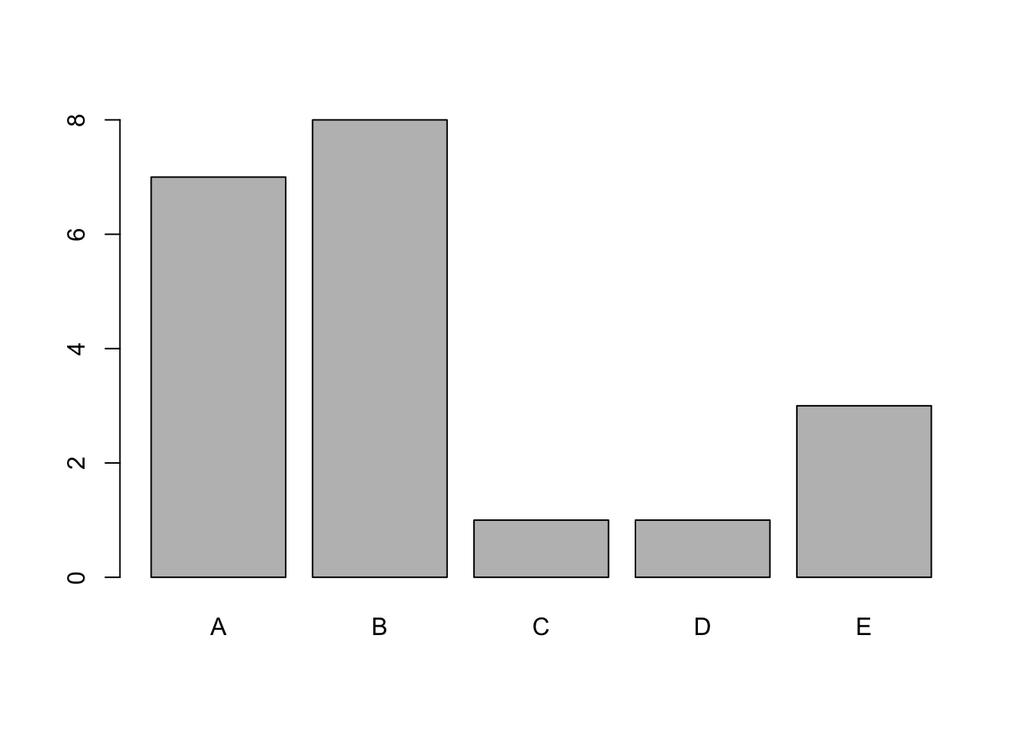

```r
predict_t <- predict(model_rf, testing)
plot(predict_t)
```

```r
predict_t
```

```
##  [1] B A B A A E D B A A B C B A E E A B B B
## Levels: A B C D E
```